# TP9

## Exercice 1

1. Les échantillons sont appariés: il s’agit de la pression sanguine du même échantillon d’individus, l’une étant la pression maximale (sys), l’autre la pression minimale (dia).

```r
data <- read.table("~/Personal/University/Semestre_4/401_STA/TP/Donnees/her.txt",header=T, sep="\t")
sys <- data$sys
dia <- data$dia
diff <- sys - dia
```

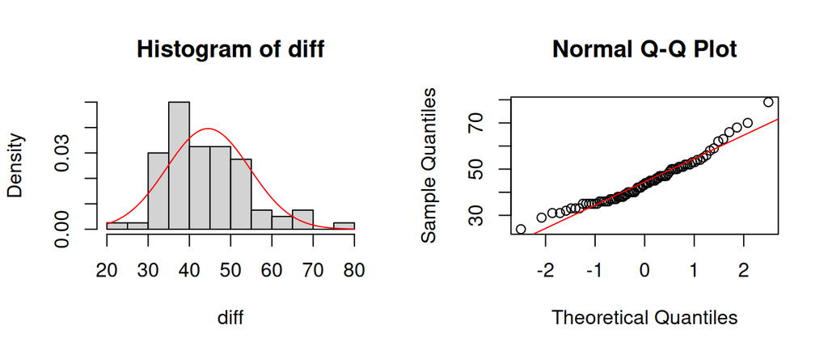

```r
par(mfrow=c(1,2))
hist(diff,probability = TRUE)
curve(dnorm(x,mean(diff),sd(diff)),col="red",add=T)
qqnorm(diff);
abline(mean(diff),sd(diff),col="red")
```

La distribution ne semble pas très éloignée de la loi normale. Mais comme n est grand, la moyenne de diff suivra elle bien une loi normale d’après le Théorème central limite (TCL).

```r
mean(diff)
```

```
## [1] 44.525
```

```r
t.test(diff, conf.level=0.95)$conf.int
```

```
## [1] 42.2825 46.7675
## attr(,"conf.level")
## [1] 0.95
```

4. H0: mean(diff)=0, H1: mean(diff) différent de zéro.

```r
tcalc <- (mean(diff)*sqrt(length(diff))/sd(diff))
cat("tcalc=",tcalc,"\n")
```

```
## tcalc= 39.52051
```

```r
pvaleur <- 2*(1-pt(abs(tcalc),length(diff)-1))
cat("pvaleur=",pvaleur,"\n")
```

```
## pvaleur= 0
```

```r
t.test(diff)
```

```
##
##  One Sample t-test
##
## data:  diff
## t = 39.521, df = 79, p-value < 2.2e-16
## alternative hypothesis: true mean is not equal to 0
## 95 percent confidence interval:
##  42.2825 46.7675
## sample estimates:
## mean of x
##    44.525
```

```r
t.test(sys,dia,paired=TRUE)
```

```
##
##  Paired t-test
##
## data:  sys and dia
## t = 39.521, df = 79, p-value < 2.2e-16
## alternative hypothesis: true mean difference is not equal to 0
## 95 percent confidence interval:
##  42.2825 46.7675
## sample estimates:
## mean difference
##          44.525
```

6. H0: mean(diff)=40, H1: mean(diff)>40

```r
t.test(diff,mu=40,alternative="greater")
```

```
##
##  One Sample t-test
##
## data:  diff
## t = 4.0164, df = 79, p-value = 6.688e-05
## alternative hypothesis: true mean is greater than 40
## 95 percent confidence interval:
##  42.64987      Inf
## sample estimates:
## mean of x
##    44.525
```

```r
# t.test(sys,dia,paired=T,mu=40,alternative="greater") # équivalent
```

La p-valeur est de 7e-5 donc oui, la conclusion est très signicafive.

## Exercice 2

1. Les échantillons ne sont pas appariés car il ne s’agit pas du même échantillon d’individus.

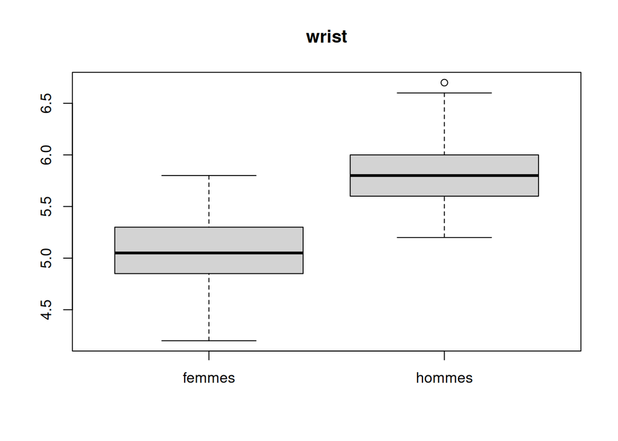

```r
wrF <- data[data$sex==1,"wrist"]
wrH <- data[data$sex==0,"wrist"]
boxplot(wrF,wrH,names=c("femmes","hommes"),main="wrist")
```

2. On doit supposer que wrF et wrH suivent des lois normales et que les 2 échantillons sont indépendants. Il faut également savoir si les variances des deux variables peuvent être supposées égales ou non. H0 : les largeurs du poignet sont égales. H1: la largeur du poignet des hommes est plus grande.

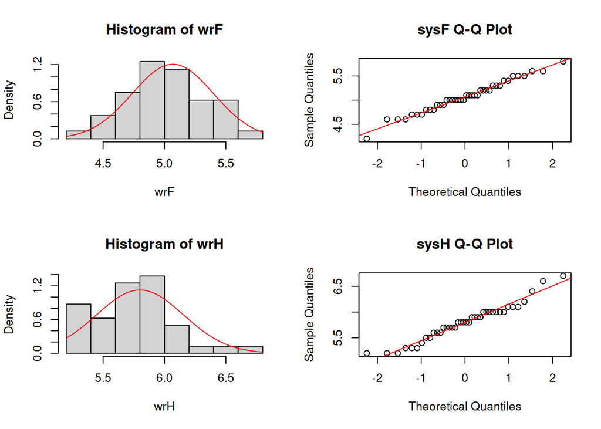

```r
par(mfrow=c(2,2))
hist(wrF,probability = TRUE)
curve(dnorm(x,mean(wrF),sd(wrF)),col="red",add=T)
qqnorm(wrF,main="sysF Q-Q Plot");
abline(mean(wrF),sd(wrF),col="red")
hist(wrH,probability = TRUE)
curve(dnorm(x,mean(wrH),sd(wrH)),col="red",add=T)
qqnorm(wrH,main="sysH Q-Q Plot");
abline(mean(wrH),sd(wrH),col="red")
```

wrF et wrH semblent pouvoir suivre des lois normales.

4. H0: les variances sont égales, H1: les variances sont différentes.

```r
tcalc <- var(wrH)/var(wrF)
pvaleur <- 2*(1-pf(tcalc,df1=length(wrH)-1,df2=length(wrF)-1))
cat("tcalc=",tcalc,"\n")
```

```
## tcalc= 1.148146
```

```r
cat("pvaleur=",pvaleur,"\n")
```

```
## pvaleur= 0.6683285
```

la p-valeur est très grande, donc pour tout risque raisonable, on ne peut pas refuser l’hypothèse H0, donc on peut l’accepter.

```r
var.test(wrH,wrF,alternative="two.sided")
```

```
##
##  F test to compare two variances
##
## data:  wrH and wrF
## F = 1.1481, num df = 39, denom df = 39, p-value = 0.6683
## alternative hypothesis: true ratio of variances is not equal to 1
## 95 percent confidence interval:
##  0.6072536 2.1708214
## sample estimates:
## ratio of variances
##           1.148146
```

```r
tcalc = sqrt((length(wrF)+length(wrH)-2)/(1/length(wrF)+1/length(wrH)))*
  (mean(wrH)-mean(wrF))/sqrt((length(wrF)-1)*var(wrF)+(length(wrH)-1)*var(wrH))
pvaleur <- 1-pt(tcalc,length(wrF)+length(wrH)-2)
cat("tcalc=",tcalc,"\n")
```

```
## tcalc= 9.555173
```

```r
cat("pvaleur=",pvaleur,"\n")
```

```
## pvaleur= 4.551914e-15
```

```r
t.test(wrH,wrF,alternative="greater", paired=F,var.equal=T)
```

```
##
##  Two Sample t-test
##
## data:  wrH and wrF
## t = 9.5552, df = 78, p-value = 4.539e-15
## alternative hypothesis: true difference in means is greater than 0
## 95 percent confidence interval:
##  0.6048898       Inf
## sample estimates:
## mean of x mean of y
##    5.8000    5.0675
```

La p-valeur est minuscule: pour tout risque de se tromper supérieur à cette p-valeur, on peut rejeter l’hypothèse H0 et donc conclure que la largeur du poignée des hommes est significativement plus grande que celle des femmes.

## Exercice 3

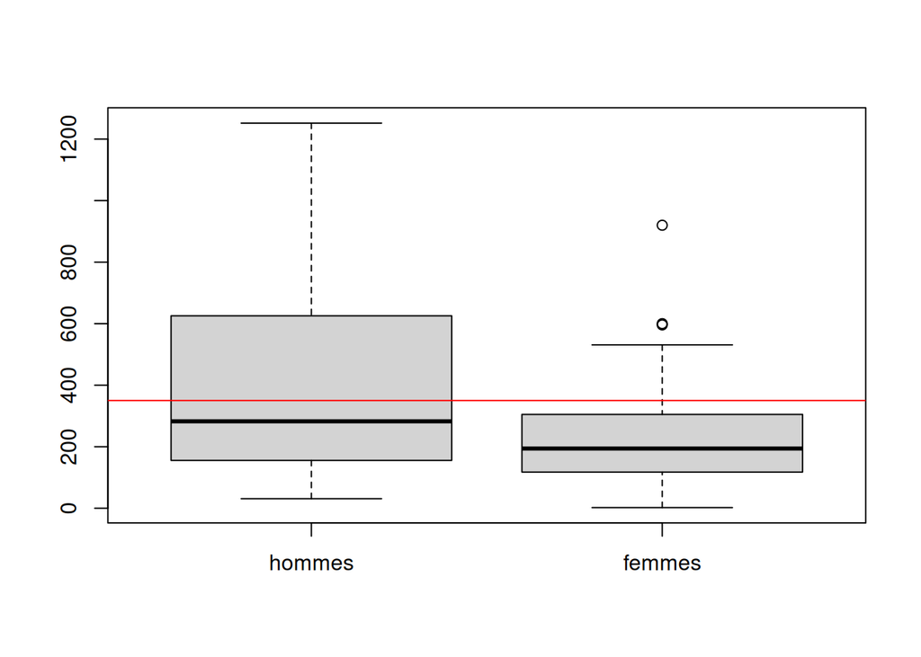

```r
cholH <- data[data$sex==0,"chol"]
cholF <- data[data$sex==1,"chol"]
boxplot(cholH, cholF, names=c("hommes","femmes"))
abline(h=350, col="red")
```

2. Test de comparaison de 2 proportions entre 2 échantillons indépendants. H0 : $p_H=p_F$ H1: $p_H$ différente de $p_F$

```r
FH = mean(cholH>350) # 0.4
FF = mean(cholF>350) # 0.175
```

```r
prop.test(c(sum(cholH>350),sum(cholF>350)),c(length(cholH),length(cholF)))
```

```
##
##  2-sample test for equality of proportions with continuity correction
##
## data:  c(sum(cholH > 350), sum(cholF > 350)) out of c(length(cholH), length(cholF))
## X-squared = 3.9054, df = 1, p-value = 0.04813
## alternative hypothesis: two.sided
## 95 percent confidence interval:
##  0.007869788 0.442130212
## sample estimates:
## prop 1 prop 2
##  0.400  0.175
```

On peut refuser H0 avec un risque $\alpha$ de se tromper de 5% et, si on accepte ce risque, on peut conclure que les hommes ont plus de chance d’avoir un cholestérol supérieur à 350 que les femmes.

4. Pour diminuer le risque de se tromper, il faudrait augmenter la taille de l’échantillon.